# Regresión lineal múltiple

## 15.9 Normalidad de los residuos

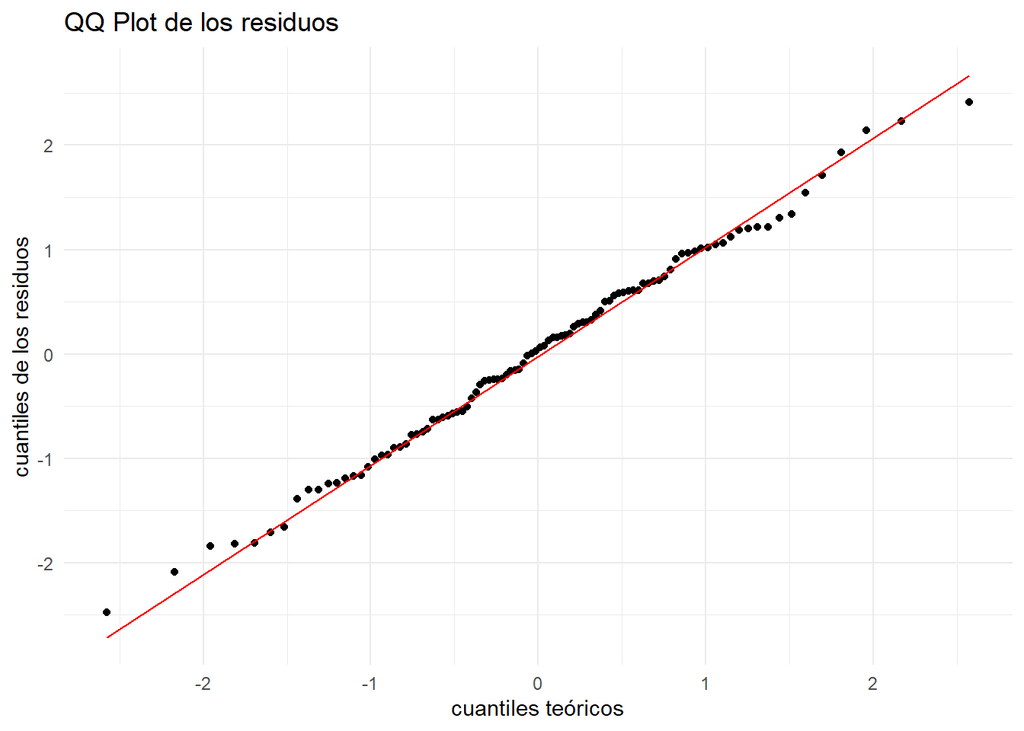

```r
residuos.df=data.frame(resid=rstandard(modelo_con_col))
ggplot(data = residuos.df, aes(sample = rstandard(modelo_con_col))) +
  stat_qq() +
  stat_qq_line(color = "red") +
  labs(title = "QQ Plot de los residuos",
       x = "cuantiles teóricos", y = "cuantiles de los residuos") +
  theme_minimal()
```

# 16 Detectando multicolinealidad

```r
library(car)

vif(modelo_sin_col)
```

```
##       x1       x2       x3
## 1.019125 1.003057 1.017576
```

```r
vif(modelo_con_col)
```

```
##         x1         x2         x3
## 354.260148   1.023393 354.548013
```

## 16.1 ¿Cómo tratar el problema de multicolinealidad?

- Lo más fácil es elegir un subconjunto de las variables regresoras poco correlacionadas.
- El asunto es… si detectamos dos variables muy correlacionadas ¿cuál omito? En general, conviene omitir aquella variable que tenga:
  - muchos datos faltantes
  - mayor error de medición.
- Otra posibilidad es utilizar métodos para eliminar variables a través de procedimientos de selección automáticos (se presentarán más adelante).
- También se puede consturir una tercer variable que sea combinación de estas variables correlacionadas. Por ejemplo: el índice de precios.

## 16.2 Métodos para tratar el problema de la multicolinealidad

- Selección de variables: con este método trabajaremos.
- Métodos de regularización o penalización. Ridge o Lasso: mejoran la estabilidad de los coeficientes, especialmente cuando hay multicolinealidad o muchas variables. Añaden un término de penalización al criterio de ajuste del modelo. Es decir, en lugar de minimizar solo el error cuadrático (como en la regresión lineal clásica), también se penalizan los coeficientes grandes.
- Métodos de reducción de la dimensión: son técnicas que reducen la cantidad de variables regresoras proyectando sobre un espacio de dimensión menor. Este método no se tratará en el curso.

# 17 Conclusión

Reformulamos el modelo eligiendo $x_1$ o $x_3$.

*Referencias:*

- Montgomery, E., Vining, D. y Peck. (2006). Introducción Al Análisis de Regresión Lineal. 3ed ed. México: Cecsa.
- James, G., Witten, D., Hastie, T., y Tibshirani, R. (2013). An introduction to statistical learning (Vol. 112). Springer.